# Time Series Project: Spring 2020

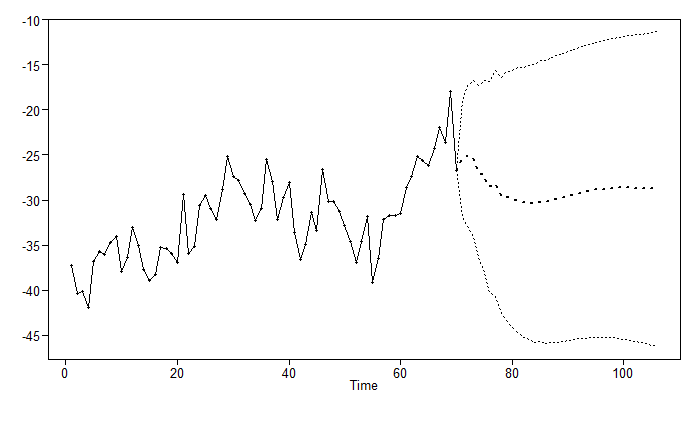

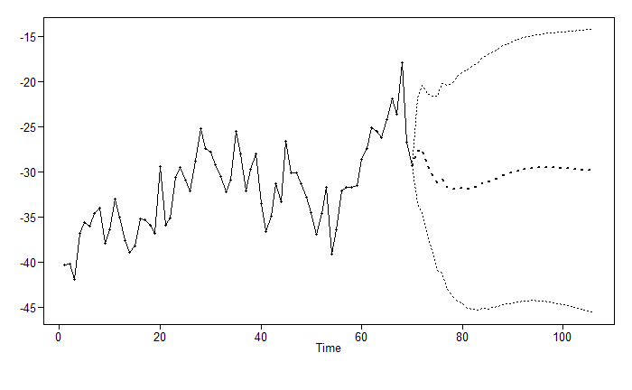

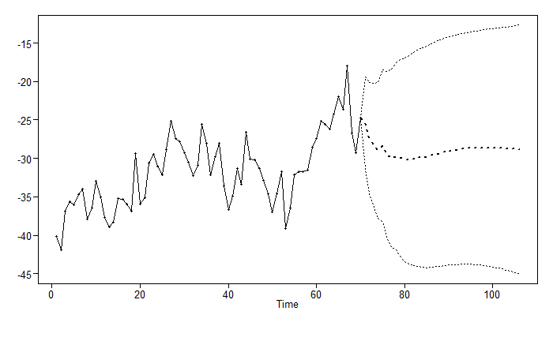

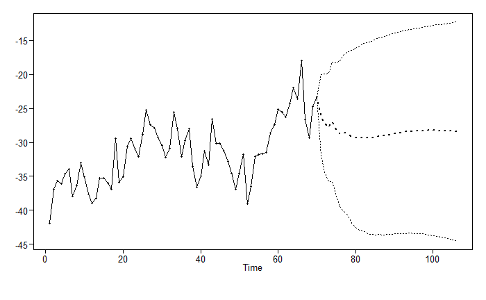

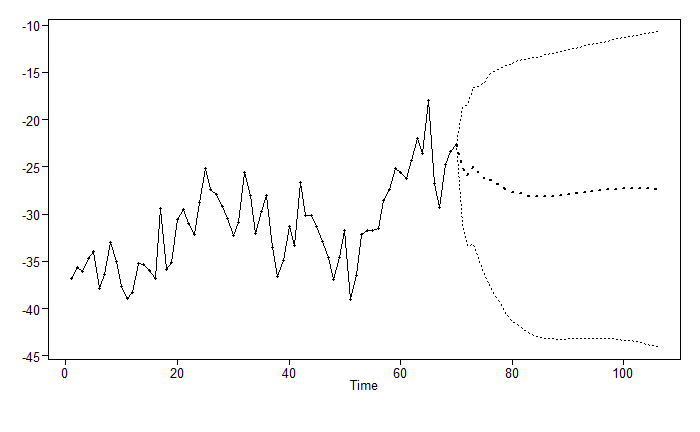

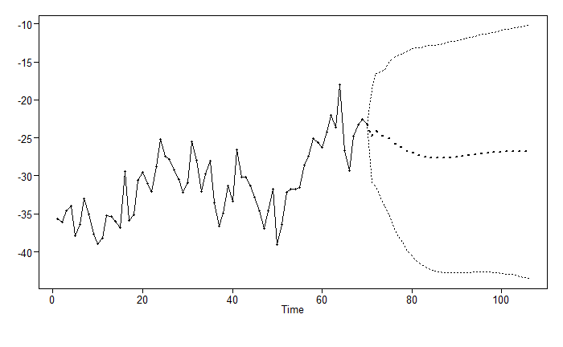

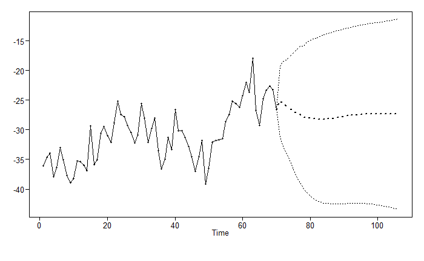

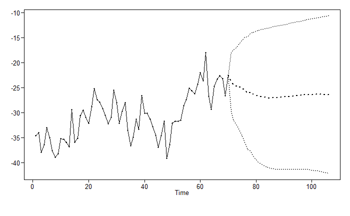

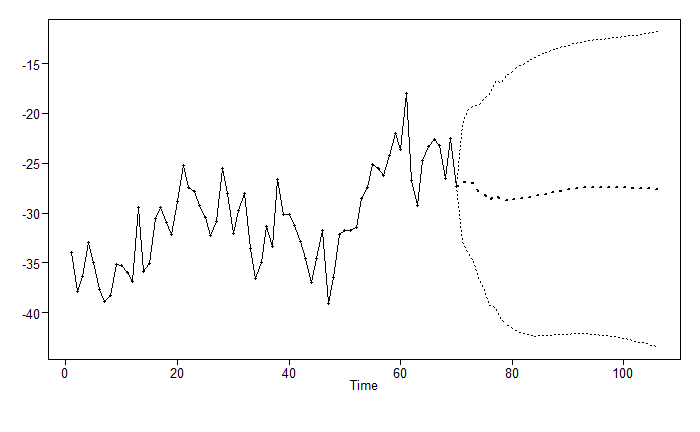

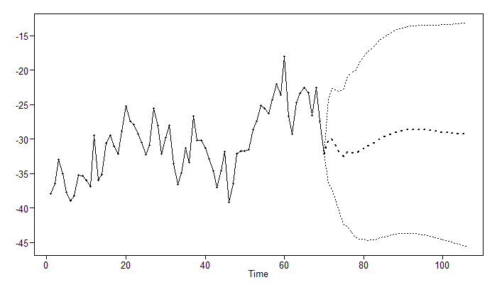

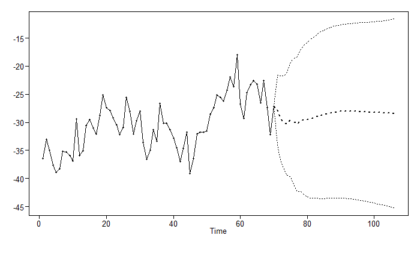

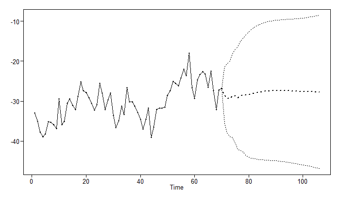

[42 more figures not shown]

```r
#rolling window ase thing test
trainingSize = 70
horizon = 36
ASEHolder = numeric()
phis = m2$phi
thetas = m2$theta
s = 0
d = 0

for( i in 1:(159-(trainingSize + horizon) + 1))
{

  forecasts = fore.aruma.wge(sea$GMSL.variation.GIA[i:(i+(trainingSize-1))],phi = phis, theta = thetas, s = s, d = d,n.ahead = horizon)

  ASE = mean((sea$GMSL.variation.GIA[(trainingSize+i):(trainingSize+ i + (horizon) - 1)] - forecasts$f)^2)

  ASEHolder[i] = ASE

}
```

```r
ASEHolder
```

```
 [1]  20.02066  31.44853  28.38184  26.49939  26.60855  27.20187  26.75782  28.48340
 [9]  26.62307  31.89682  27.62598  26.22041  30.01841  26.52531  25.62516  25.97151
[17]  26.30751  36.29023  29.80042  26.03320  24.27041  25.13782  29.20917  24.86351
[25]  32.18259  32.58610  34.37406  28.47844  24.70749  20.26089  21.03641  32.35634
[33]  27.52565  26.29747  24.16379  26.69880  31.22631  35.89403 104.08645  34.72812
[41]  27.57631  27.66629  27.84914  30.64831  39.42394  32.62540  29.72381  27.32911
[49]  29.63533  28.05639  28.69364  32.03467  37.55112  31.79674
```

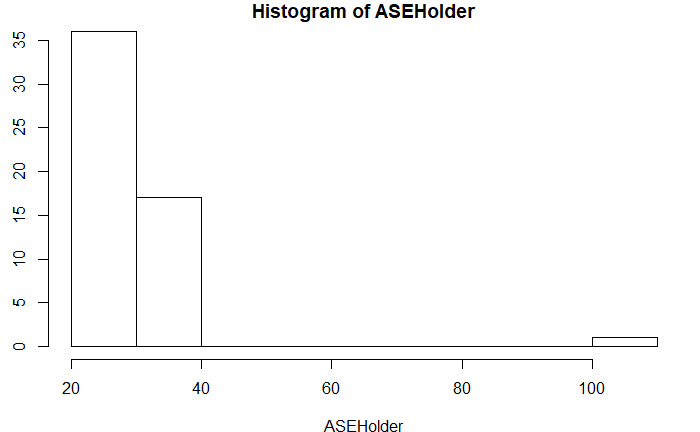

```r
hist(ASEHolder)
```

```r
WindowedASE = mean(ASEHolder)

summary(ASEHolder)
```

```
   Min. 1st Qu.  Median    Mean 3rd Qu.    Max.
  20.02   26.36   27.95   30.09   31.71  104.09
```

```r
WindowedASE
```

```
[1] 30.09323
```

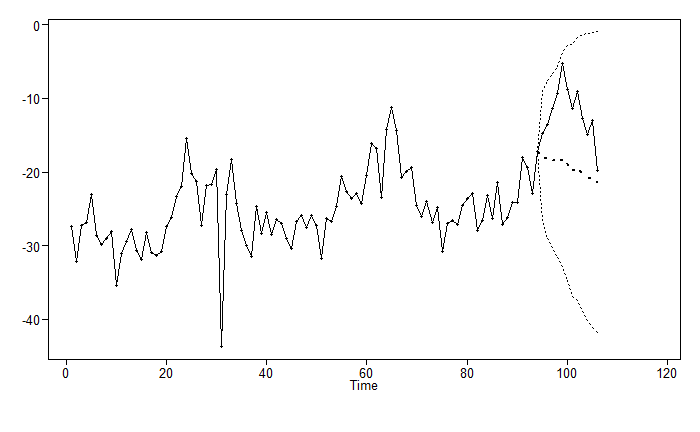

```r
# Visualization

i = 78
fs = fore.aruma.wge(sea$GMSL.variation.GIA[i:(i+(trainingSize+horizon)-1)],phi = phis, theta = thetas, s = s, d = d,n.ahead = 12, lastn = TRUE)
```

```r
ASE = mean((sea$GMSL.variation.GIA[(i+trainingSize):(i+(trainingSize+horizon)-1)] - fs$f )^2)
roll.ase2 = ASE
ASE
```

```
[1] 48.68947
```

##seasonal model

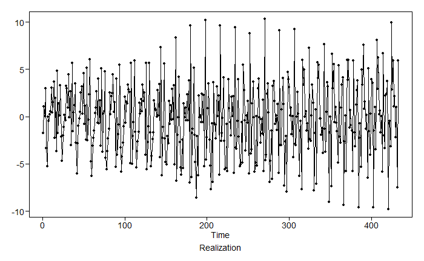

```r
#seasonal model testing
sample.s36 = gen.aruma.wge(n = 432, s = 18, sn = 1342)
```

```r
est.ar.wge(sample.s36, p = 36, type = "burg") #guessing s = 36??
```

[output not shown]

[output cut: 64 more lines]

```
[415] -0.554949690  0.088134588  1.780858718 -1.363049914 -0.005177415 -0.637716806
[421]  1.147249054 -1.044240310  0.312480712  2.413066732  0.008422843 -0.182945814
[427]  0.745502977  1.711024692 -0.464509766  1.020768414 -1.445850161 -0.534212128

$avar
[1] 0.9079833

$aic
[1] 0.07476703

$aicc
[1] 1.096855

$bic
[1] 0.4232201
```

```r
est.ar.wge(sea$GMSL.variation.GIA, p = 30, type = "burg")
```

```
Coefficients of Original polynomial:
0.6432 0.0894 0.1526 0.1580 -0.0186 -0.0133 -0.1077 0.0784 -0.0958 0.0331 -0.0751 0.0130 -0.0053 -0.0521 0.1102 -0.0082 0.0796 -0.0284 -0.0177 0.0151 -0.0269 -0.0462 -0.0272 0.0497 -0.0477 -0.0287 0.0110 0.0668 0.0548 0.0430

Factor                 Roots                Abs Recip    System Freq
1-0.9997B              1.0003               0.9997       0.0000
1-1.9367B+0.9638B^2    1.0047+-0.1677i      0.9817       0.0263
1-1.8096B+0.9359B^2    0.9668+-0.3658i      0.9674       0.0576
1-0.0608B+0.8849B^2    0.0343+-1.0625i      0.9407       0.2449
1-1.5052B+0.8741B^2    0.8610+-0.6346i      0.9349       0.1011
1-0.5093B+0.8690B^2    0.2930+-1.0320i      0.9322       0.2060
1-0.8783B+0.8637B^2    0.5084+-0.9483i      0.9294       0.1717
1-1.2470B+0.8584B^2    0.7263+-0.7984i      0.9265       0.1325
1+1.7789B+0.8267B^2   -1.0760+-0.2280i      0.9092       0.4668
1+0.9032B             -1.1072               0.9032       0.5000
1+0.9026B+0.8157B^2   -0.5533+-0.9591i      0.9031       0.3333
```

[output cut: 192 more lines]

some matches, just go with s = 18 for now

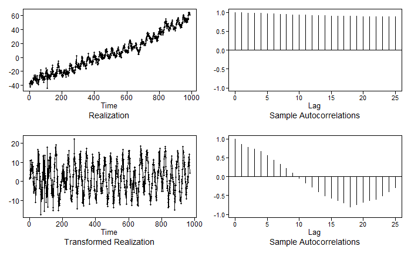

```r
#transform data
y = artrans.wge(sea$GMSL.variation.GIA, phi.tr = c(rep(0,17), 1))
```

s = 36 not really stationary, s = 18 maybe though??

[output not shown]

[output cut: 206 more lines]

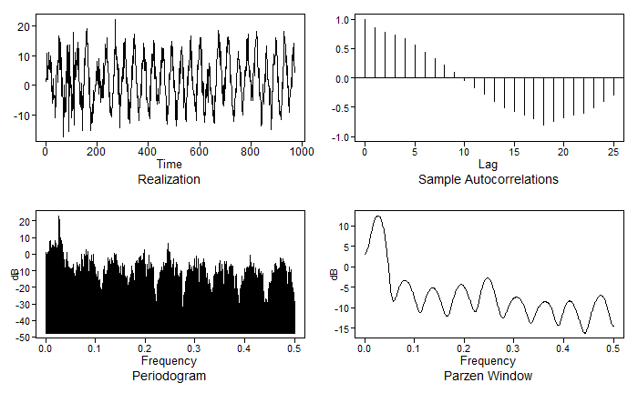

```r
plotts.sample.wge(y)
```

transformed data looks to have 9 ish frequencies?

```r
aic5.wge(y, p = 0:12, q = 0:6)
```

```
---------WORKING... PLEASE WAIT...
```

[output not shown]

```
Five Smallest Values of  aic
```

|  | p | q | aic |
| --- | --- | --- | --- |
| 75 | 10 | 4 | 2.407512 |
| 45 | 6 | 2 | 2.431554 |
| 87 | 12 | 2 | 2.433371 |
| 73 | 10 | 2 | 2.440971 |
| 66 | 9 | 2 | 2.441816 |

AIC is lowest for 10, 4, but going with 9 2, to make an arima(9, 18, 2)

```r
m3 = est.arma.wge(sea$GMSL.variation.GIA, p = 9, q = 2)
```

```
possible convergence problem: optim gave code = 1
```

```
Coefficients of Original polynomial:
-0.9713 0.3964 0.9948 0.5133 0.3637 0.0351 -0.1871 -0.1112 -0.0400

Factor                 Roots                Abs Recip    System Freq
1-0.9985B              1.0015               0.9985       0.0000
1+1.6521B+0.9123B^2   -0.9055+-0.5256i      0.9551       0.4163
1-0.1872B+0.4716B^2    0.1984+-1.4426i      0.6867       0.2282
1+0.6823B             -1.4657               0.6823       0.5000
1-0.6677B              1.4977               0.6677       0.0000
1+0.4904B+0.2046B^2   -1.1984+-1.8578i      0.4523       0.3412
```

```r
m3$phi
```

```
[1] -0.97131823  0.39644095  0.99482457  0.51328710  0.36371220  0.03509629 -0.18712053
[8] -0.11120737 -0.04004108
```

```r
m3$theta
```

```
[1] -1.6969149 -0.9308516
```

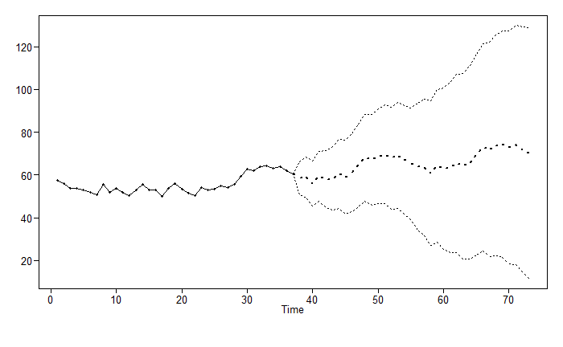

```r
f3 = fore.aruma.wge(sea$GMSL.variation.GIA[952:988], phi = m3$phi, theta = m3$theta, d = 0, s = 18, n.ahead = 36)
```

```r
#36 entries per year, predict sea level variation 1 year at current rate

#ase3 = mean((sea$GMSL.variation.GIA[(length(sea$GMSL.variation.GIA)-35):length(sea$GMSL.variation.GIA)] - f3$f)^2)
ase3 = mean((sea$GMSL.variation.GIA[952:988]-f3$f)^2)
```

```
longer object length is not a multiple of shorter object length
```

```r
paste("average squared error for ARUMA(9, 18, 2): ", ase3)
```

```
[1] "average squared error for ARUMA(9, 18, 2):  117.217801761978"
```

```r
mean(sea$GMSL.variation.GIA)
```

```
[1] 6.240941
```

```r
#(1+0.97131823B  -0.39644095B^2  -0.99482457B^3  -0.51328710B^4 -0.36371220B^5  -0.03509629B^6 +0.18712053B^7 +0.11120737B^8 +0.04004108B^9)(1-B^18) = (1+1.6969149B + 0.9308516B^2)*at, var= 6.983474
```

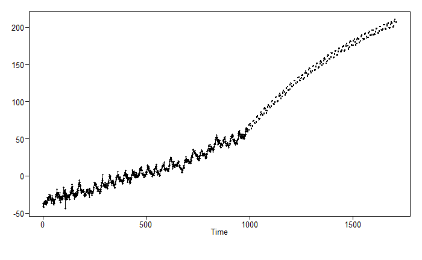

```r
f3.2 = fore.aruma.wge(sea$GMSL.variation.GIA[1:(length(sea$GMSL.variation.GIA))], phi = m3$phi, theta = m3$theta, s = 18, n.ahead = 720, limits = FALSE)
```

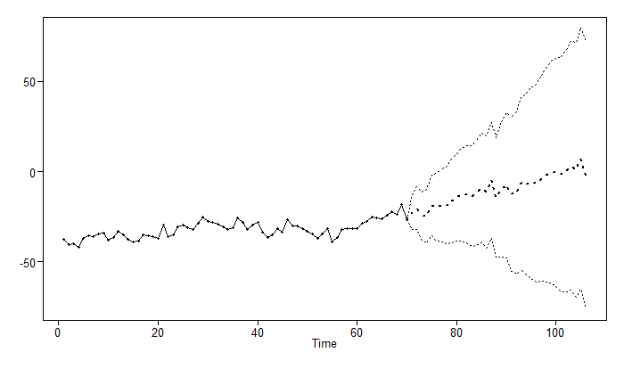

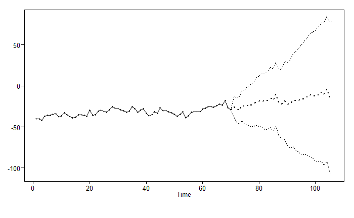

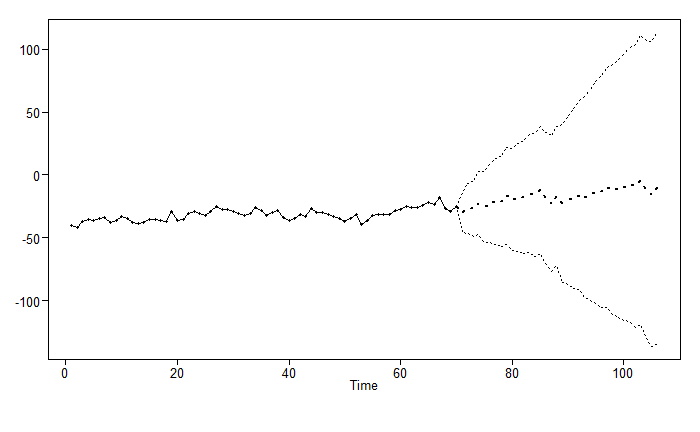

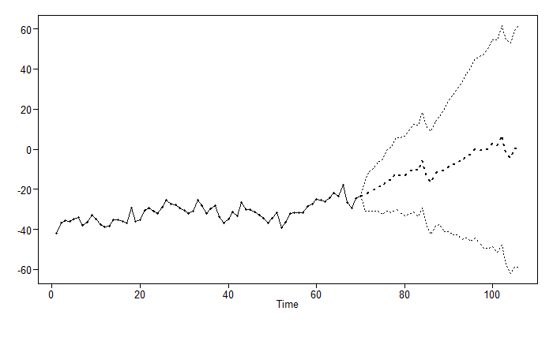

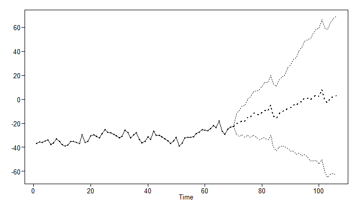

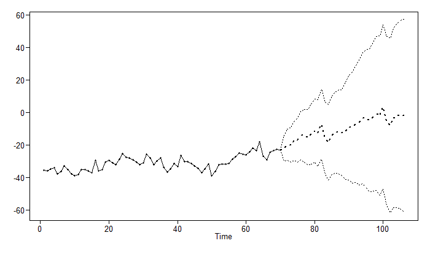

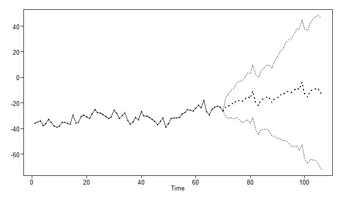

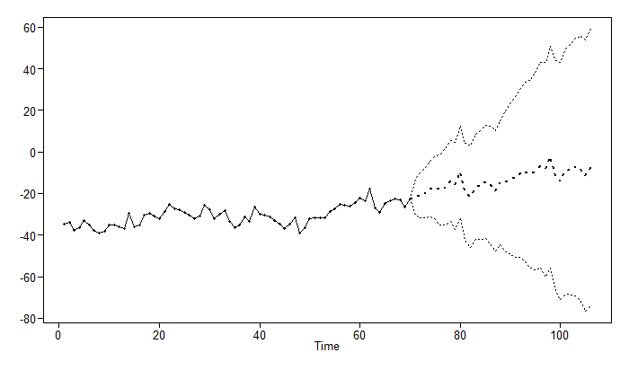

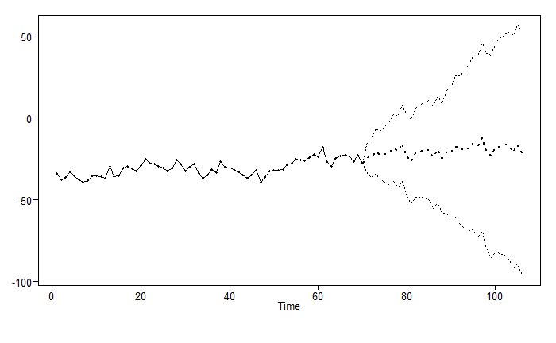

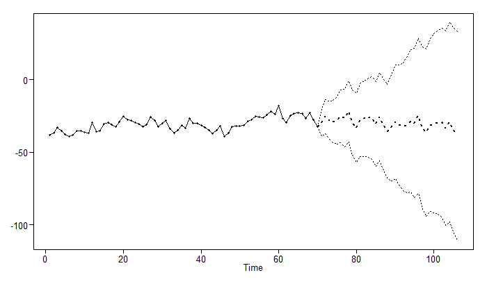

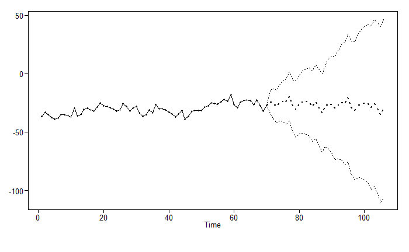

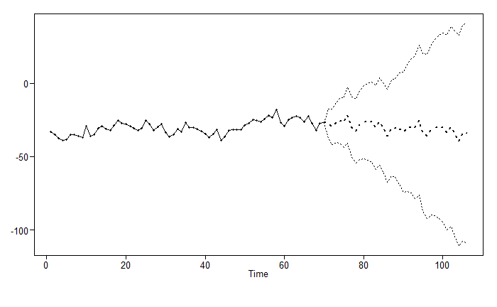

[42 more figures not shown]

```r
#rolling window ase for model 3
trainingSize = 70
horizon = 36
ASEHolder = numeric()
phis = m3$phi
thetas = m3$theta
s = 18
d = 0

for( i in 1:(159-(trainingSize + horizon) + 1))
{

  forecasts = fore.aruma.wge(sea$GMSL.variation.GIA[i:(i+(trainingSize-1))],phi = phis, theta = thetas, s = s, d = d,n.ahead = horizon)

  ASE = mean((sea$GMSL.variation.GIA[(trainingSize+i):(trainingSize+ i + (horizon) - 1)] - forecasts$f)^2)

  ASEHolder[i] = ASE

}
```

```r
ASEHolder
```

```
 [1] 349.46231 119.18248 158.74106 415.44530 456.20230 339.38872 178.18954 218.38288
 [9]  83.36948  56.88401  42.04043  60.66833  47.47947  51.46506  71.53867 158.64955
[17] 139.00271 690.92851 198.31767  59.08487  60.97407 107.18418 235.70661 175.10602
[25] 173.65100 261.98891 124.33061  36.64265  34.47027  49.89157  43.25286 283.06618
[33] 248.17684 229.37517  53.80110 275.02087 176.22223 243.02654 396.51936  48.64204
[41] 188.07762  79.07704 122.81353  57.55741  62.75288  59.06261  76.37896  79.32732
[49] 184.03497 423.44808 370.06131 320.99640 184.25824 163.02657
```

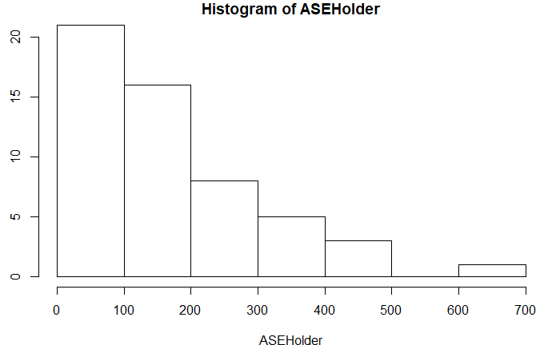

```r
hist(ASEHolder)
```

```r
WindowedASE = mean(ASEHolder)

summary(ASEHolder)
```

```
   Min. 1st Qu.  Median    Mean 3rd Qu.    Max.
  34.47   60.74  158.70  176.34  241.20  690.93
```

```r
WindowedASE
```

```
[1] 176.3397
```

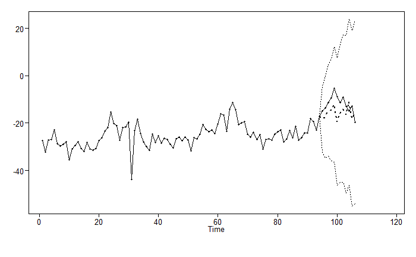

```r
# Visualization

i = 78
fs = fore.aruma.wge(sea$GMSL.variation.GIA[i:(i+(trainingSize+horizon)-1)],phi = phis, theta = thetas, s = s, d = d,n.ahead = 12, lastn = TRUE)
```

```r
ASE = mean((sea$GMSL.variation.GIA[(i+trainingSize):(i+(trainingSize+horizon)-1)] - fs$f )^2)
roll.ase3 = ASE
ASE
```

```
[1] 73.02997
```

## stationarity testing

Initial visualization looks pretty wander-y, check to see if roots are within unit circle

```r
#factor.wge(sea$GMSL.variation.GIA)
```

```r
#sig plus noise section
x = sea$GMSL.variation.GIA
t = seq(1, length(x), 1)
df = data.frame(x = x, t = t)
fit = lm(x~t, data = df)
#again, note that summary of fit will usually give very different results from summary of cfit
cfit = cochrane.orcutt(fit) #cfit is better, less false positives
print("hypothesis testing for linear trend regression")
```

```
[1] "hypothesis testing for linear trend regression"
```

```r
summary(fit)
```

```
Call:
lm(formula = x ~ t, data = df)

Residuals:
     Min       1Q   Median       3Q      Max
-17.7388  -4.1538  -0.2551   3.6536  17.2049

Coefficients:
              Estimate Std. Error t value Pr(>|t|)
(Intercept) -3.844e+01  3.587e-01  -107.1   <2e-16 ***
t            9.035e-02  6.284e-04   143.8   <2e-16 ***
---
Signif. codes:  0 ‘***’ 0.001 ‘**’ 0.01 ‘*’ 0.05 ‘.’ 0.1 ‘ ’ 1

Residual standard error: 5.634 on 986 degrees of freedom
Multiple R-squared:  0.9545,    Adjusted R-squared:  0.9544
F-statistic: 2.067e+04 on 1 and 986 DF,  p-value: < 2.2e-16
```

```r
print("hypothesis testing for corchrane orcutt trend analysis")
```

```
[1] "hypothesis testing for corchrane orcutt trend analysis"
```

```r
summary(cfit)
```

```
Call:
lm(formula = x ~ t, data = df)

               Estimate  Std. Error t value  Pr(>|t|)
(Intercept) -38.6162414   1.4297483 -27.009 < 2.2e-16 ***
t             0.0908270   0.0024764  36.678 < 2.2e-16 ***
---
Signif. codes:  0 ‘***’ 0.001 ‘**’ 0.01 ‘*’ 0.05 ‘.’ 0.1 ‘ ’ 1

Residual standard error: 2.7168 on 985 degrees of freedom
Multiple R-squared:  0.5773 ,  Adjusted R-squared:  0.5769
F-statistic: 1345.3 on 1 and 985 DF,  p-value: < 2.216e-186

Durbin-Watson statistic
(original):    0.24733 , p-value: 4.811e-168
(transformed): 2.31460 , p-value: 1e+00
```

pvalue for slope is = <2e-16, reject H0; 95% confident that residuals are not white noise?

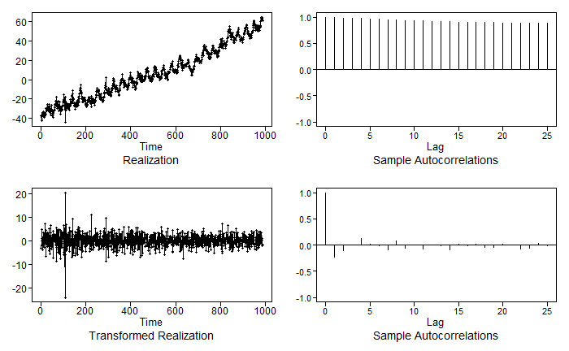

```r
#take first difference to check for white noise
d1 = artrans.wge(sea$GMSL.variation.GIA, phi.tr = 1)
```

##Rest of the analysis - VAR with explanatory variable - Neural Network - Ensamble model

6. forecast horizon (multiples of 36 points for years)
7. ppt and 7 min video
8. post ppt and video to google doc and 2ds